# OZNAL - zadanie 1, 2

Daniel Cok, Jakub Abrahoim

Ako dataset sme zvolili štatistiky hráčov z NHL, ktorý je dostupný [tu](https://www.kaggle.com/datasets/alexbenzik/nhl-players-statistics?resource=download&select=NHL_Players_Statistics.csv). Dataset obsahuje dáta o hráčoch NHL z viacerých sezón

# Načítanie knižníc

```r
library(tidyverse)
library(magrittr)
library(data.table) # Pre %like% operátor
library(caret) # Pre confusionMatrix
library(pROC)
library(glmnet) # Lasso
library(e1071) # SVM
```

# Načítanie dát

```r
getwd()
```

```
## [1] "/Users/jakub/Documents/FIIT/OZNAL/2024/OZNAL_Zadania"
```

```r
# /Users/danielcok/xcok/4.semester/OZNAL/Zadanie
# /Users/jakub/Documents/FIIT/OZNAL/2024/OZNAL_Zadania
setwd("/Users/jakub/Documents/FIIT/OZNAL/2024/OZNAL_Zadania") # Set the correct path to players_22.csv
data <- read_delim("NHL_Players_Statistics.csv", col_names = TRUE, num_threads = 4, delim = ';');
data
```

```
## # A tibble: 27,319 × 40
##    Name     Date_of_…¹ SEASO…² SEASON TEAM  Games…³ Goals Assists Points PlusM…⁴
##    <chr>    <date>       <dbl> <chr>  <chr>   <dbl> <dbl>   <dbl>  <dbl>   <dbl>
##  1 Aaron D… 1974-08-27    2000 '99-'… BOS         1     0       0      0       0
##  2 Aaron D… 1974-08-27    2001 '00-'… CHI         3     0       0      0      -1
##  3 Aaron D… 1974-08-27    2002 '01-'… CHI        36     1       0      1      -2
##  4 Aaron D… 1974-08-27    2003 '02-'… DAL        43     1       1      2       1
##  5 Aaron D… 1974-08-27    2004 '03-'… DAL        37     1       1      2       2
##  6 Aaron D… 1974-08-27    2006 '05-'… MTL        25     1       4      5       2
##  7 Aaron D… 1974-08-27    2006 '05-'… STL        17     2       0      2       0
##  8 Aaron D… 1974-08-27    2007 '06-'… MTL        21     1       0      1      -6
##  9 Aaron D… 1974-08-27    2008 '07-'… DET        56     0       3      3       0
## 10 Aaron D… 1974-08-27    2009 '08-'… DET         4     1       1      2       0
## # … with 27,309 more rows, 30 more variables: Penalty_Minutes <dbl>,
## #   Shots_on_Goal <dbl>, Shooting_Percentage <dbl>, PowerPlay_Goals <dbl>,
## #   PowerPlay_Assists <dbl>, Short_Goals <dbl>, Short_Assists <dbl>,
## #   Game_Winning_Goals <dbl>, Game_Tying_Goals <dbl>,
## #   Time_on_Ice_per_Game <time>, Production <chr>, Number <dbl>,
## #   Games_Started <dbl>, Wins <dbl>, Losses <dbl>, Ties <dbl>,
## #   Overtime_Losses <dbl>, Goals_Against <dbl>, Goals_Against_Average <dbl>, …
```

```r
view(data)
```

# Úprava dát

Ako prvé sme upravili názvy stĺpcov, aby boli konzistentné nakoľko niektoré boli all caps a niektoré nie. Taktiež sme niektoré premenovali, aby boli jasnejšie.

```r
colnames(data) # Pôvodné mená stĺpcov
```

```
##  [1] "Name"                  "Date_of_birth"         "SEASON_year"
##  [4] "SEASON"                "TEAM"                  "Games_Played"
##  [7] "Goals"                 "Assists"               "Points"
## [10] "PlusMinus_Ratings"     "Penalty_Minutes"       "Shots_on_Goal"
## [13] "Shooting_Percentage"   "PowerPlay_Goals"       "PowerPlay_Assists"
## [16] "Short_Goals"           "Short_Assists"         "Game_Winning_Goals"
## [19] "Game_Tying_Goals"      "Time_on_Ice_per_Game"  "Production"
## [22] "Number"                "Games_Started"         "Wins"
## [25] "Losses"                "Ties"                  "Overtime_Losses"
## [28] "Goals_Against"         "Goals_Against_Average" "Shots_Against"
## [31] "Saves"                 "Save_Percentage"       "Shutouts"
## [34] "Position"              "Height"                "Weight"
## [37] "Body_mass_index"       "Place_of_birth"        "Age"
## [40] "Experience"
```

```r
new_colnames <- c("player_name", "date_of_birth", "season_year", "season", "team", "games_played", "goals", "assists", "points", "plus_minus_ratings", "penalty_minutes",
                "shots_on_goal", "shooting_percentage", "power_play_goals", "power_play_assists", "short_goals", "short_assists", "game_winning_goals", "game_tying_goals",
                "time_on_ice_per_game", "production", "number", "games_started", "wins", "losses", "ties", "overtime_losses", "goals_against", "goals_against_average", "shots_against", "saves",
                "save_percentage", "shutouts", "position", "height", "weight", "bmi", "place_of_birth", "age", "experience")

colnames(data) <- new_colnames

colnames(data) # Nové mená stĺpcov
```

```
##  [1] "player_name"           "date_of_birth"         "season_year"
##  [4] "season"                "team"                  "games_played"
##  [7] "goals"                 "assists"               "points"
## [10] "plus_minus_ratings"    "penalty_minutes"       "shots_on_goal"
## [13] "shooting_percentage"   "power_play_goals"      "power_play_assists"
## [16] "short_goals"           "short_assists"         "game_winning_goals"
## [19] "game_tying_goals"      "time_on_ice_per_game"  "production"
## [22] "number"                "games_started"         "wins"
## [25] "losses"                "ties"                  "overtime_losses"
## [28] "goals_against"         "goals_against_average" "shots_against"
## [31] "saves"                 "save_percentage"       "shutouts"
## [34] "position"              "height"                "weight"
## [37] "bmi"                   "place_of_birth"        "age"
## [40] "experience"
```

Stĺpec `date_of_birth` rozdelíme na 3 stĺpce `Year`, `Month` a `Day` nakoľko to boli 3 hodnoty v jednej bunke (zachovanie princípu tidy dát).

```r
data %<>% separate("date_of_birth", into = c("Year", "Month", "Day"), sep = "-")
```

Stĺpec `place_of_birth` rozdelíme na 2 stĺpce `city` a `state` nakoľko to boli 2 hodnoty v jednej bunke (zachovanie princípu tidy dát). Ak mal hráč iba mesto, tak `state` bude automaticky `NA`.

```r
data %<>% separate("place_of_birth", into = c("city", "state"), sep = ",")
```

Odstránenie apostrofov z hodnôt v stĺpci `season`. Dáta v tomto sĺpci boli formátované ako ‘<číslo>-’<číslo>. Apostrofy nám prišli zbytočné a tak sme ich odstránili pre lepšiu čitateľnosť.

```r
data$season <- gsub("'", "", data$season) # Funkcia gsub funguje podobne ako sub ale nahradí všetky výskyty
```

Odstránenie invalid values zo sĺpcov nakoľko pri analýze datasetu sme objavili, že niektoré bunky v daných sĺpcoch obsahujú `Invalid Number`. Nahradíme ich za `0`.

```r
data$game_tying_goals[is.na(data$game_tying_goals)] <- 0
data$number[is.na(data$number)] <- 0
data$goals[is.na(data$goals)] <- 0
data$assists[is.na(data$assists)] <- 0
data$points[is.na(data$points)] <- 0
data$plus_minus_ratings[is.na(data$plus_minus_ratings)] <- 0
data$penalty_minutes[is.na(data$penalty_minutes)] <- 0
data$shots_on_goal[is.na(data$shots_on_goal)] <- 0
data$shooting_percentage[is.na(data$shooting_percentage)] <- 0
data$power_play_goals[is.na(data$power_play_goals)] <- 0
data$power_play_assists[is.na(data$power_play_assists)] <- 0
data$short_goals[is.na(data$short_goals)] <- 0
data$short_assists[is.na(data$short_assists)] <- 0
data$game_winning_goals[is.na(data$game_winning_goals)] <- 0
```

```r
# Získame unikátne hodnoty z pozícií hráčov
unique(data$position)
```

```
## [1] "Right_wing" "Centre"     "Defence"    "Left_wing"  "Goaltender"
## [6] "Forward"
```

```r
data %<>% mutate(
  role = case_when(
    position %like% "Right_wing|Left_wing|Center|Forward" ~ "offensive",
    position %like% "Defence" ~ "defensive",
    position %like% "Goaltender" ~ "goalie",
    .default = "goalie"
  )
)
```

```r
# Vytvorenie stĺpca role_oneHot na základe pozície
data <- data %>%
  mutate(
    role_oneHot = if_else(role == "offensive", 1, 0)
  )
```

Zobrazenie dát po úprave.

```r
view(data)
```

# Lineárna regresia

Ako prvé sme si vybrali niektoré sĺpce z datasetu a použili funkciu plot na vykreslenie grafov. Ako závislú (dependent) premennú sme si zvolili `goals` a ako nezávislé (independent) premenné sme si zvolili `shots_on_goal`, `shooting_percentage`. Vychádzali sme z výstupu príkazu `plot` ale aj logického odhadu, že tieto premenné by mohli mať vplyv na počet gólov. - `goals` - počet gólov - `shots_on_goal` - počet striel na bránu - `shooting_percentage` - percentuálna úspešnosť striel

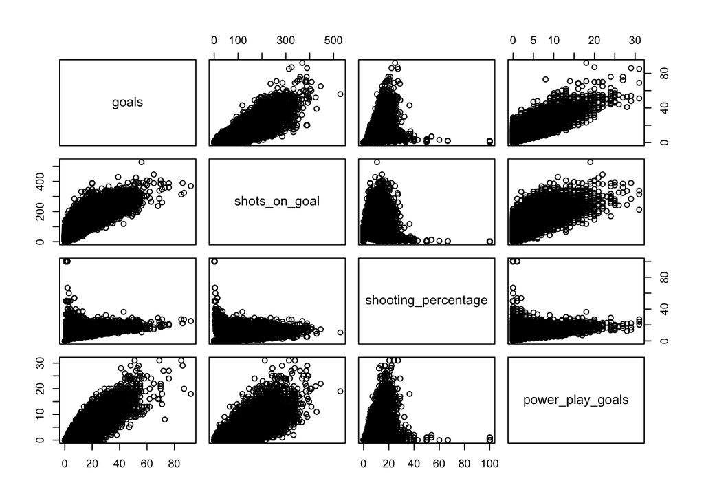

```r
selected_data <- data %>% select(goals, shots_on_goal, shooting_percentage, power_play_goals)
plot(selected_data)
```

```r
#boxplot(selected_data)
```

Hypotézy: - H_0 - Strely na bránu majú pozitívny vplyv na počet gólov - H_1 - Percentuálna úspešnosť striel má pozitívny vplyv na počet gólov

Pri lineárnej regresii budeme uvažovať ofenzívnych a defenzívnych hráčov, nakoľko v reálnych hokejových zápasoch často skóruju obe tieto skupiny. Brankárov brať do úvahy nebudeme. Preto sme si najprv vyfiltrovali dáta pomocou funkcie `filter` a vybrali iba ofenzívnych a defenzívnych hráčov podľa sĺpcu `role`, ktorý sme si vyššie vytvorili. Následne sme si rozdelili dáta na trénovacie a testovacie v pomere 7:3 a následne sme vytvorili lineárny model pomocou funkcie `lm`.

```r
# Filter na offensive a defensive
filtered_data <- data %>% filter(role == "offensive" | role == "defensive")

sample <- sample(c(TRUE, FALSE), nrow(filtered_data), replace=TRUE, prob=c(0.7,0.3))
train <- filtered_data[sample, ]
test <- filtered_data[!sample, ]

model <- lm(goals ~ shots_on_goal + shooting_percentage, data = train)
summary(model)
```

```
##
## Call:
## lm(formula = goals ~ shots_on_goal + shooting_percentage, data = train)
##
## Residuals:
##     Min      1Q  Median      3Q     Max
## -27.205  -1.839  -0.088   2.328  38.251
##
## Coefficients:
##                       Estimate Std. Error t value Pr(>|t|)
## (Intercept)         -3.1679667  0.0575716  -55.03   <2e-16 ***
## shots_on_goal        0.1050285  0.0005201  201.93   <2e-16 ***
## shooting_percentage  0.3126809  0.0049857   62.72   <2e-16 ***
## ---
## Signif. codes:  0 '***' 0.001 '**' 0.01 '*' 0.05 '.' 0.1 ' ' 1
##
## Residual standard error: 4.052 on 13073 degrees of freedom
## Multiple R-squared:  0.8112, Adjusted R-squared:  0.8111
## F-statistic: 2.808e+04 on 2 and 13073 DF,  p-value: < 2.2e-16
```

Interpretácia modelu:

Reziduály:

Vykreslenie reziduálov pomocou funkcie `plot`.

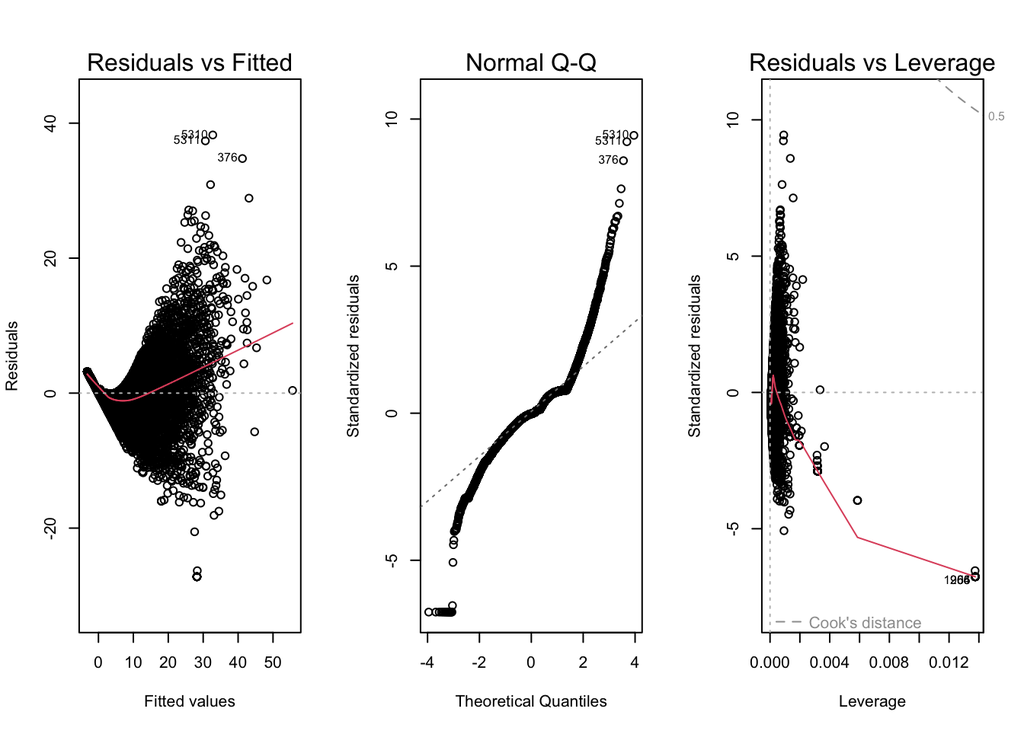

```r
par(mfrow = c(1,3)) # Vytvorí grid 1x3
plot(model, which = c(1,2,5))
```

Výpočet RSS (residual sum of squares) a RMSE (root mean squared error). * RSS - Suma/súčet druhej mocniny vzdialenosti medzi skutočnými hodnotami a predikovanými hodnotami. Čím nižšie RSS tým lepší model. * RMSE - Odmocnina priemeru druhej mocniny residuálov. Priemerný rozdiel (chyba) medzi skutočnými hodnotami a predikovanými hodnotami. Čím nižšie RMSE tým lepší model.

```r
# Pre trénovacie dáta
residuals <- model$residuals
RSS <- sum(residuals^2)
RSS
```

```
## [1] 214601.3
```

```r
RMSE <- sqrt(mean(residuals^2))
RMSE
```

```
## [1] 4.051154
```

```r
# Pre testovacie dáta
predictions <- predict(model, test)
residuals_test <- test$goals - predictions
RSS_test <- sum(residuals_test^2)
RSS_test
```

```
## [1] 96283.33
```

```r
RMSE_test <- RMSE(predictions, test$goals)
RMSE_test
```

```
## [1] 4.134335
```

# Logistická regresia

Hypotézy:

- **H0** : Počet gólov má pozitivny vplyv na pravdepodobnosť byť klasifikovaný ako ofenzívny hráč.
- **H1** : Asistencie maju negativny vplyv na pravdepodobnosť byť klasifikovaný ako ofenzívny hráč.

```r
# Rozdelenie dát na trenovaciu a testovaciu súpravu
set.seed(123)
training_indices <- createDataPartition(data$role_oneHot, p = 0.7, list = FALSE)
train_data <- data[training_indices, ]
test_data <- data[-training_indices, ]
```

set.seed(123): Toto nastaví náhodný generátor čísel na konkrétnu hodnotu (123), aby bolo možné reprodukovanie rozdelenia dát; to znamená, že vždy keď tento kód spustíte, dostanete rovnaké rozdelenie dát.

createDataPartition(data$role_oneHot, p = 0.7, list = FALSE): Funkcia createDataPartition z knižnice caret rozdelí dátový rámec tak, že 70% dát (ako je uvedené v p = 0.7) sa použije na trénovanie modelu a zvyšok (30%) na jeho testovanie. Argument list = FALSE hovorí, že funkcia by mala vrátiť priamo indexy namiesto zoznamu indexov.

train_data <- data[training_indices, ]: Tento riadok vytvorí trénovaciu súpravu použitím indexov vrátených createDataPartition.

test_data <- data[-training_indices, ]: Podobne tento riadok vytvorí testovaciu súpravu použitím zvyšných indexov, ktoré neboli vybrané pre trénovanie.

```r
# Vytvorenie logistického regresného modelu
model <- glm(role_oneHot ~ goals + assists , data = train_data, family = "binomial")
```

```r
# Predikcie a hodnotenie
predictions <- predict(model, test_data, type = "response")
predicted_class <- if_else(predictions > 0.5, 1, 0)
```

Výpočet predikcií pomocou funkcie predict, kde argument type = “response” znamená, že predikcie sú na škále pravdepodobnosti, čiže hodnoty medzi 0 a 1, kde hodnoty bližšie k 1 indikujú väčšiu istotu, že pozorovanie patrí do pozitívnej triedy (často označovanej ako 1).

Vytvorenie predpovedanej triedy predicted_class pomocou funkcie if_else, kde sa prahová hodnota 0.5 používa na určenie, či by malo byť pozorovanie klasifikované ako pozitívne (1) alebo negatívne (0). Ak je predpovedaná pravdepodobnosť väčšia ako 0.5, pozorovanie sa klasifikuje ako pozitívne; inak sa klasifikuje ako negatívne.

```r
# Confusion matrix
cm <- confusionMatrix(as.factor(predicted_class), as.factor(test_data$role_oneHot), positive =  "1")
print(cm)
```

```
## Confusion Matrix and Statistics
##
##           Reference
## Prediction    0    1
##          0 4763 2119
##          1  418  895
##
##                Accuracy : 0.6904
##                  95% CI : (0.6803, 0.7004)
##     No Information Rate : 0.6322
##     P-Value [Acc > NIR] : < 2.2e-16
##
##                   Kappa : 0.2452
##
##  Mcnemar's Test P-Value : < 2.2e-16
##
##             Sensitivity : 0.2969
##             Specificity : 0.9193
##          Pos Pred Value : 0.6816
##          Neg Pred Value : 0.6921
##              Prevalence : 0.3678
##          Detection Rate : 0.1092
##    Detection Prevalence : 0.1602
##       Balanced Accuracy : 0.6081
##
##        'Positive' Class : 1
##
```